# R Notebook

## Hypothesis test - “Not strong” belonging and access to green space

The test was significant at the 99.99% level (p < 0.01). This means that we can reject the null hypothesis that there is no significant difference in the mean percentages of people who rated their feeling of belonging in their community as “not strong” between the group of people who can access a green space within a 10 minute walk and the group of people who have to walk over 10 minutes to access a green space. Specifically, on average, fewer people who had to walk less than 10 min to access a green space rated their feeling of belonging as “not strong” (19.19%) than people who had to walk further to access a green space (24.21%).

| walking_distance_to_nearest_greenspace | mean_percentage |
| --- | --- |
| Less than 10 minutes | 19.19048 |
| More than 10 minutes | 24.20968 |

### Hypothesis

H0 - There is no significant difference in the mean percentages of people assigning “not strong” feelings of belonging ratings based on their access to a green space.

H1 - There is a significant difference in the mean percentages of people assigning “not strong” feelings of belonging ratings based on their access to a green space.

### Box plots

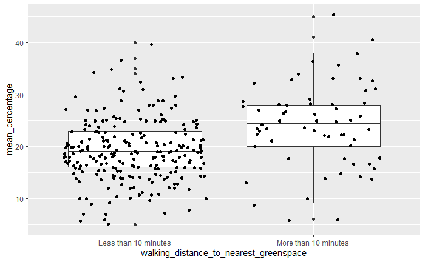

```r
comb_belonging %>%
filter(belonging_binary == "Not strong") %>%
  ggplot(aes(x = walking_distance_to_nearest_greenspace,
             y = mean_percentage))+
  geom_boxplot() +
  geom_jitter()
```

### Two sample difference in means test - Not strong belonging ratings

```r
#generate the null distribution
null_distribution <- comb_belonging %>%
filter(belonging_binary == "Not strong") %>% #specify "Good" ratings as the value of interest
  specify(mean_percentage ~ walking_distance_to_nearest_greenspace) %>%
  hypothesise(null = "independence") %>%
  generate(reps = 5000, type = "permute") %>%
  calculate(stat = "diff in means", order = c("Less than 10 minutes",
                                              "More than 10 minutes"))
```

```
Dropping unused factor levels c("Don't Know", "All") from the supplied explanatory variable 'walking_distance_to_nearest_greenspace'.
```

```r
observed_stat <- comb_belonging %>%
filter(belonging_binary == "Not strong") %>% #specify "Not strong" ratings as the value of interest
  specify(mean_percentage ~ walking_distance_to_nearest_greenspace) %>%
  calculate(stat = "diff in means", order = c("Less than 10 minutes",
                                              "More than 10 minutes"))
```

```
Dropping unused factor levels c("Don't Know", "All") from the supplied explanatory variable 'walking_distance_to_nearest_greenspace'.
```

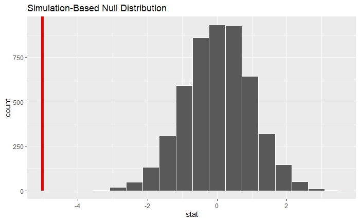

```r
null_distribution %>%
  visualise()+
  shade_pvalue(obs_stat = observed_stat, direction = "both")
```

```r
null_distribution %>%
  get_p_value(obs_stat = observed_stat, direction = "both")
```

| p_value |
| --- |
| 0 |

### LA comparison - Good and poor access to green space

```r
comb_belonging %>%
  filter(ca_name %in% c("West Dunbartonshire", "East Lothian")) %>%
  group_by(ca_name, belonging_binary) %>%
  summarise(mean_percentage = mean(mean_percentage))
```

| ca_name | belonging_binary | mean_percentage |
| --- | --- | --- |
| East Lothian | Not strong | 20.28571 |
| East Lothian | Strong | 79.14286 |
| West Dunbartonshire | Not strong | 26.20000 |
| West Dunbartonshire | Strong | 72.70000 |